# How to Calculate the SVD from Scratch with Python

**Matrix decomposition**, also known as matrix factorization, involves describing a given matrix using its constituent elements.

Perhaps the most known and widely used matrix decomposition method is the Singular-Value Decomposition, or SVD. All matrices have an SVD, which makes it more stable than other methods, such as the eigendecomposition. As such, it is often used in a wide array of applications including compressing, denoising, and data reduction.

In this tutorial, you will discover the Singular-Value Decomposition method for decomposing a matrix into its constituent elements. After completing this tutorial, you will know:

- What Singular-value decomposition is and what is involved.
- How to calculate an SVD and reconstruct a rectangular and square matrix from SVD elements.
- How to calculate the pseudoinverse and perform dimensionality reduction using the SVD.

## Singular-Value Decomposition

The Singular-Value Decomposition, or SVD for short, is a matrix decomposition method for reducing a matrix to its constituent parts in order to make certain subsequent matrix calculations simpler.

For the case of simplicity we will focus on the SVD for real-valued matrices and ignore the case for complex numbers.

A = U . Sigma . V<sup>T</sup>

Where *A* is the real *m x n* matrix that we wish to decompose, *U* is an *m x m* matrix, Sigma (often represented by the uppercase Greek letter Sigma) is an *m x n* diagonal matrix, and *V<sup>T</sup>* is the transpose of an *n x n* matrix where *T* is a superscript.

## The SVD can be calculated by calling the svd() function.

The function takes a matrix and returns the U, Sigma and V<sup>T</sup> elements. The Sigma diagonal matrix is returned as a vector of singular values. The V matrix is returned in a transposed form, e.g. V.T.

The example below defines a 3×2 matrix and calculates the Singular-value decomposition.

```python
from numpy import array, diag, dot, zeros
from scipy.linalg import svd
from sklearn.decomposition import TruncatedSVD

import matplotlib.pyplot as plt
import numpy as np
```

```python
# Singular-value decomposition

# define a matrix
A = array([[1, 2], [3, 4], [5, 6]])
print(A)
```

```
[[1 2]
 [3 4]
 [5 6]]
```

```python
plt.imshow(A, cmap='hot', interpolation='nearest')
plt.show()
```

[output not shown]

```python
# SVD
U, s, VT = svd(A)
```

Running the example first prints the defined 3×2 matrix, then the 3×3 U matrix, 2 element Sigma vector, and 2×2 V<sup>T</sup> matrix elements calculated from the decomposition.

```python
print(U)
```

```
[[-0.2298477   0.88346102  0.40824829]
 [-0.52474482  0.24078249 -0.81649658]
 [-0.81964194 -0.40189603  0.40824829]]
```

```python
print(s)
```

```
[9.52551809 0.51430058]
```

```python
print(VT)
```

```
[[-0.61962948 -0.78489445]
 [-0.78489445  0.61962948]]
```

## Reconstruct Matrix from SVD

The original matrix can be reconstructed from the U, Sigma, and V<sup>T</sup> elements.

The U, s, and V elements returned from the *svd()* cannot be multiplied directly.

The s vector must be converted into a diagonal matrix using the *diag(*) function. By default, this function will create a square matrix that is *n x n*, relative to our original matrix. This causes a problem as the size of the matrices do not fit the rules of matrix multiplication, where the number of columns in a matrix must match the number of rows in the subsequent matrix.

After creating the square Sigma diagonal matrix, the sizes of the matrices are relative to the original *m x n* matrix that we are decomposing, as follows:

U (m x m) . Sigma (n x n) . V<sup>T</sup> (n x n)

We can achieve this by creating a new Sigma matrix of all zero values that is *m x n* (e.g. more rows) and populate the first n x n part of the matrix with the square diagonal matrix calculated via *diag()*.

```python
# Reconstruct SVD

# define a matrix
A = array([[1, 2], [3, 4], [5, 6]])
print(A)
# Singular-value decomposition
U, s, VT = svd(A)
# create m x n Sigma matrix
Sigma = zeros((A.shape[0], A.shape[1]))
# populate Sigma with n x n diagonal matrix
Sigma[:A.shape[1], :A.shape[1]] = diag(s)
# reconstruct matrix
B = U.dot(Sigma.dot(VT))
print(B)
```

```
[[1 2]
 [3 4]
 [5 6]]
[[1. 2.]
 [3. 4.]
 [5. 6.]]
```

```python
plt.imshow(A, cmap='hot', interpolation='nearest')
plt.show()

plt.imshow(B, cmap='hot', interpolation='nearest')
plt.show()
```

[output not shown]

Running the example first prints the original matrix, then the matrix reconstructed from the SVD elements. The above complication with the Sigma diagonal only exists with the case where m and n are not equal. The diagonal matrix can be used directly when reconstructing a square matrix, as follows.

```python
# Reconstruct SVD

# define a matrix
A = array([[1, 2, 3], [4, 5, 6], [7, 8, 9]])
print(A)
# Singular-value decomposition
U, s, VT = svd(A)
# create n x n Sigma matrix
Sigma = diag(s)
# reconstruct matrix
B = U.dot(Sigma.dot(VT))
print(B)
```

```
[[1 2 3]
 [4 5 6]
 [7 8 9]]
[[1. 2. 3.]
 [4. 5. 6.]
 [7. 8. 9.]]
```

Running the example prints the original 3×3 matrix and the version reconstructed directly from the SVD elements.

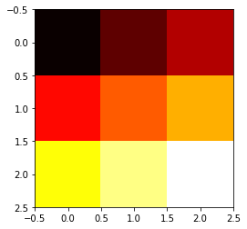

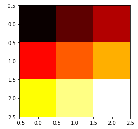

```python
plt.imshow(A, cmap='hot', interpolation='nearest')
plt.show()

plt.imshow(B, cmap='hot', interpolation='nearest')
plt.show()
```

## SVD for Dimensionality Reduction

A popular application of SVD is for dimensionality reduction.

Data with a large number of features, such as more features (columns) than observations (rows) may be reduced to a smaller subset of features that are most relevant to the prediction problem.

The result is a matrix with a lower rank that is said to approximate the original matrix.

To do this we can perform an SVD operation on the original data and select the top k largest singular values in Sigma. These columns can be selected from Sigma and the rows selected from V^T.

An approximate B of the original vector A can then be reconstructed.

B = U . Sigmak . V<sup>k</sup>

In natural language processing, this approach can be used on matrices of word occurrences or word frequencies in documents and is called Latent Semantic Analysis or Latent Semantic Indexing.

In practice, we can retain and work with a descriptive subset of the data called T. This is a dense summary of the matrix or a projection.

T = U . Sigmak

Further, this transform can be calculated and applied to the original matrix A as well as other similar matrices.

T = V^k . A

The example below demonstrates data reduction with the SVD.

First a 3×10 matrix is defined, with more columns than rows. The SVD is calculated and only the first two features are selected. The elements are recombined to give an accurate reproduction of the original matrix. Finally the transform is calculated two different ways.

```python
# define a matrix
A = array([
	[1,2,3,4,5,6,7,8,9,10],
	[11,12,13,14,15,16,17,18,19,20],
	[21,22,23,24,25,26,27,28,29,30]])
print(A)
```

```
[[ 1  2  3  4  5  6  7  8  9 10]
 [11 12 13 14 15 16 17 18 19 20]
 [21 22 23 24 25 26 27 28 29 30]]
```

```python
plt.imshow(A, cmap='hot', interpolation='nearest')
plt.show()
```

[output not shown]

```python
# Singular-value decomposition
U, s, VT = svd(A)
# create m x n Sigma matrix
Sigma = zeros((A.shape[0], A.shape[1]))
# populate Sigma with n x n diagonal matrix
Sigma[:A.shape[0], :A.shape[0]] = diag(s)
# select
n_elements = 2
Sigma = Sigma[:, :n_elements]
VT = VT[:n_elements, :]
```

```python
# reconstruct
B = U.dot(Sigma.dot(VT))
print(B)
# transform
T = U.dot(Sigma)
print(T)
```

```
[[ 1.  2.  3.  4.  5.  6.  7.  8.  9. 10.]
 [11. 12. 13. 14. 15. 16. 17. 18. 19. 20.]
 [21. 22. 23. 24. 25. 26. 27. 28. 29. 30.]]
[[-18.52157747   6.47697214]
 [-49.81310011   1.91182038]
 [-81.10462276  -2.65333138]]
```

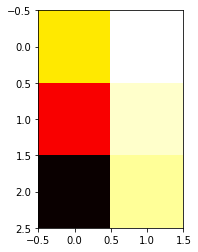

```python
plt.imshow(B, cmap='hot', interpolation='nearest')
plt.show()

plt.imshow(T, cmap='hot', interpolation='nearest')
plt.show()
```

[output not shown]

```python
T = A.dot(VT.T)
print(T)
```

```
[[-18.52157747   6.47697214]
 [-49.81310011   1.91182038]
 [-81.10462276  -2.65333138]]
```

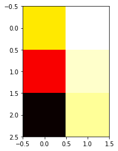

```python
plt.imshow(T, cmap='hot', interpolation='nearest')
plt.show()
```

The scikit-learn provides a TruncatedSVD class that implements this capability directly.

The TruncatedSVD class can be created in which you must specify the number of desirable features or components to select, e.g. 2. Once created, you can fit the transform (e.g. calculate V^Tk) by calling the fit() function, then apply it to the original matrix by calling the transform() function. The result is the transform of A called T above.

The example below demonstrates the TruncatedSVD class.

```python
# define array
A = array([
	[1,2,3,4,5,6,7,8,9,10],
	[11,12,13,14,15,16,17,18,19,20],
	[21,22,23,24,25,26,27,28,29,30]])
print(A)
# svd
svd = TruncatedSVD(n_components=2)
svd.fit(A)
B = svd.transform(A)
print(B)
```

```
[[ 1  2  3  4  5  6  7  8  9 10]
 [11 12 13 14 15 16 17 18 19 20]
 [21 22 23 24 25 26 27 28 29 30]]
[[18.52157747  6.47697214]
 [49.81310011  1.91182038]
 [81.10462276 -2.65333138]]
```

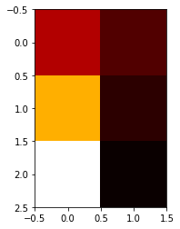

```python
plt.imshow(A, cmap='hot', interpolation='nearest')
plt.show()

plt.imshow(B, cmap='hot', interpolation='nearest')
plt.show()
```

[output not shown]

Running the example first prints the defined matrix, followed by the transformed version of the matrix.

We can see that the values match those calculated manually above, except for the sign on some values. We can expect there to be some instability when it comes to the sign given the nature of the calculations involved and the differences in the underlying libraries and methods used. This instability of sign should not be a problem in practice as long as the transform is trained for reuse.